# Red Wine Quality EDA by Anas Haneya

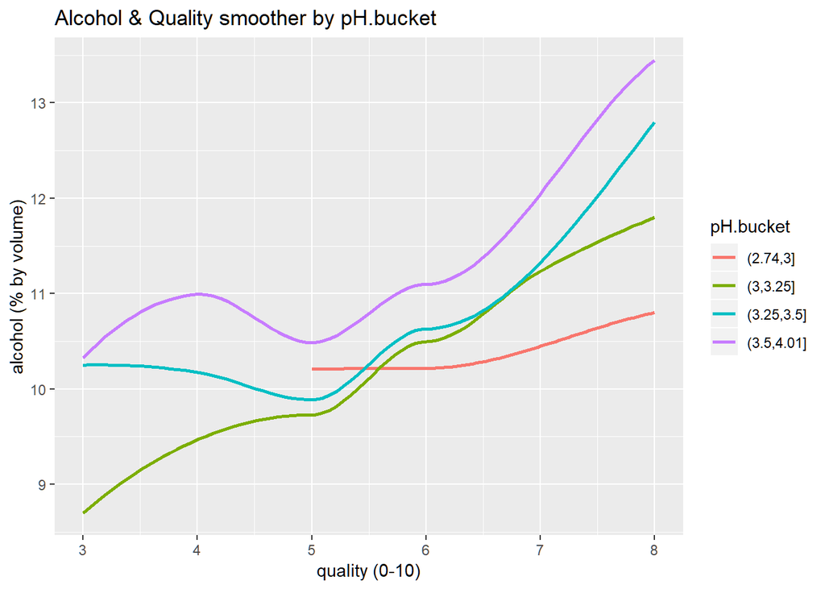

As per the above plot, I see that for pH values 3.25-3.5 and 3.5-4.01  
and higher percentage of alcohol contributes to higher levels of quality

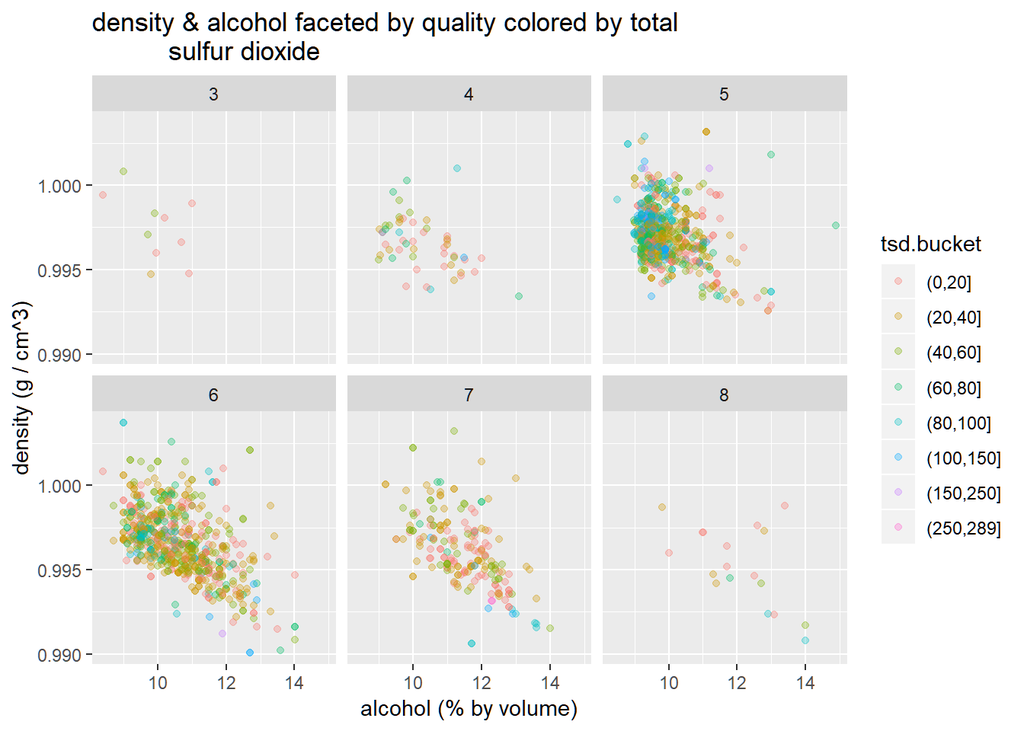

following on my previous findings on total sulfur dioxide, in the above plot  
I can see buckets (20,40] and (40,60] also the relatively lower density and  
higher alcohol contributes to better quality

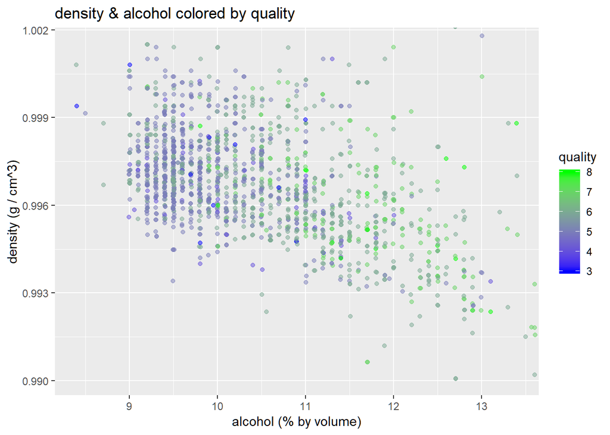

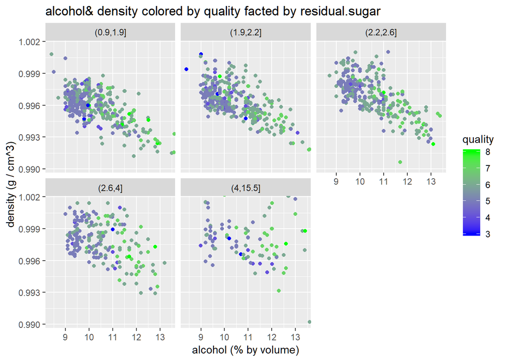

**Residual.sugar doesn’t have an influence on the quality, as in the plot**

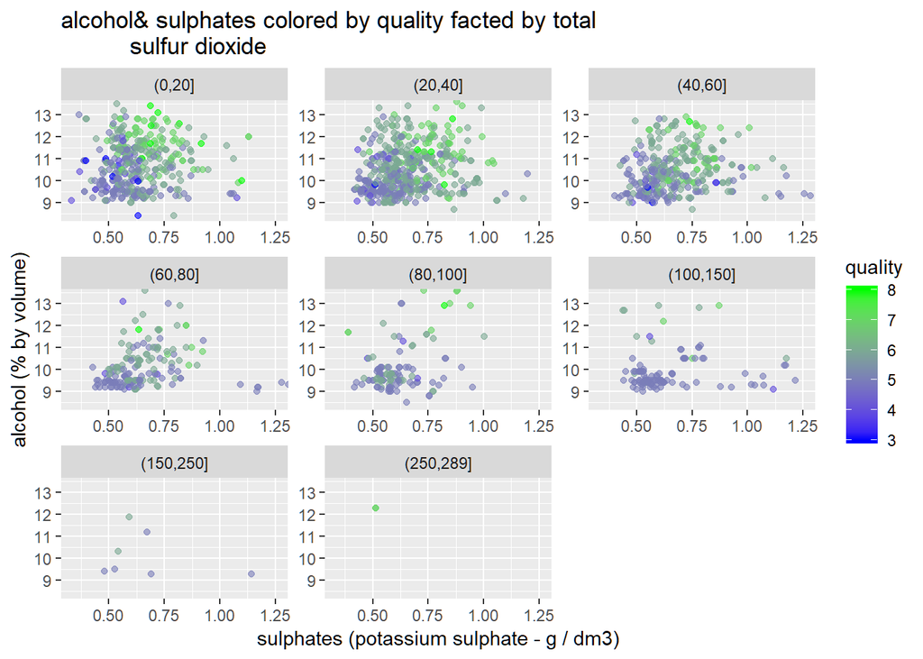

# Multivariate Analysis

### Talk about some of the relationships you observed in this part of the investigation. Were there features that strengthened each other in terms of looking at your feature(s) of interest?

Adding more features against each other allowed to explore relation between  
features of interest and against the outcome variable, which allowed me to  
conclude what feature has the most effect and what is the optimum value for  
each

### Interesting relation in the EDA.

I have found out that on average a sulphates value of around 0.8 can mean a  
good quality red wine

Sulphates is an interesting feature I wasn’t expecting to have an impact on  
red wine quality

while also some features are strongly correlated but it doesn’t mean it will  
have a direct affect on quality ——

# Final Plots and Summary

### Plot One

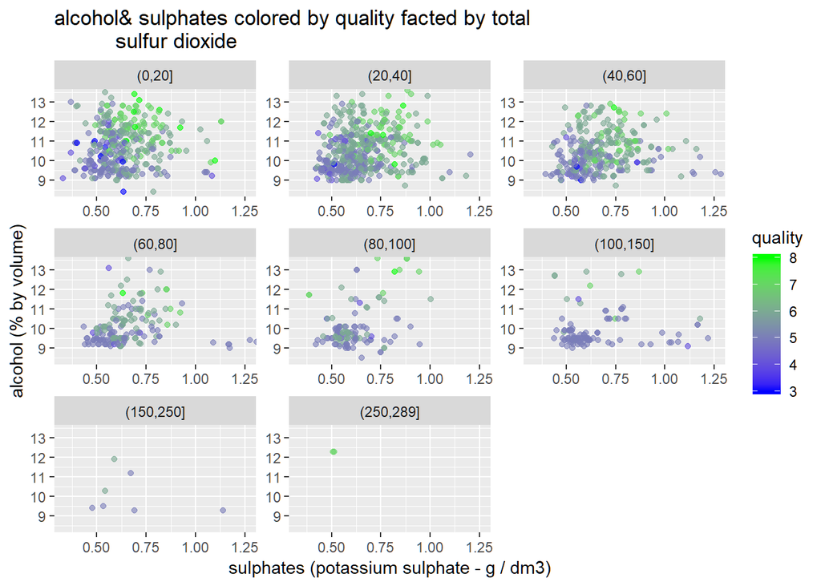

### Plot Two

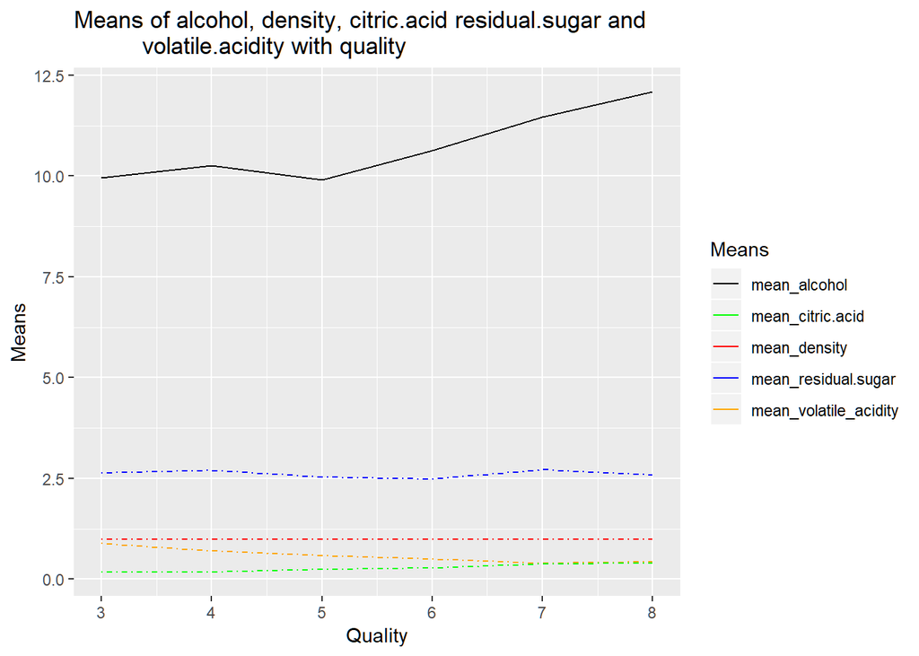

### Description Two

This is an excellent plot that shows on average what contributes directly to  
quality which is in this case alcohol, volatile acidity, citric acid

### Plot Three

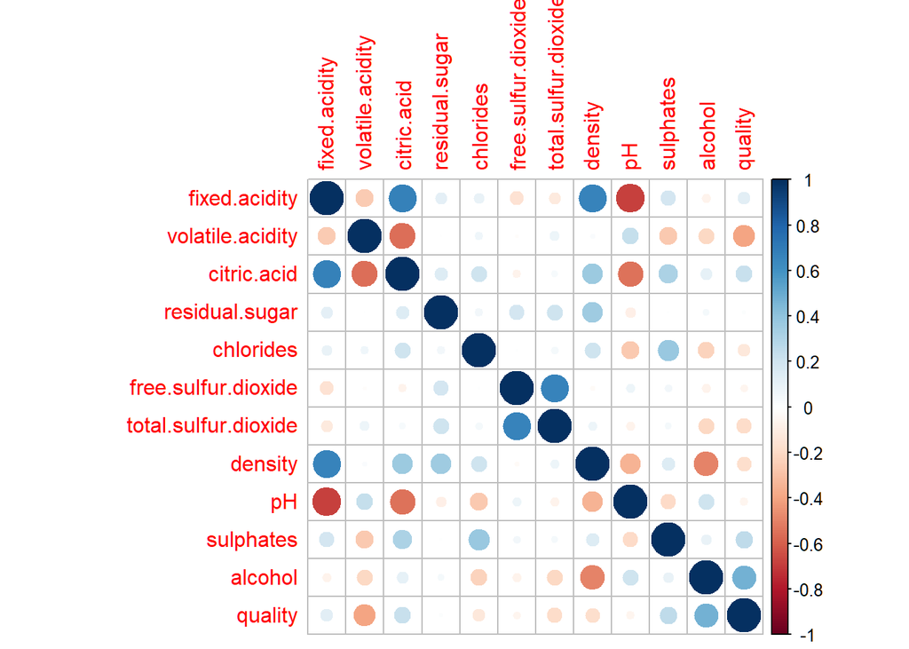

### Description Three

This plot gives an idea on what to work on right away, its a starting point  
especially for the multivariate analysis, this plot show the strong, weak and  
moderate correlation between variables, as a second step in the analysis,  
I would use 2 correlated features to add one or 2 more to enhance the  
analysis

# Reflection

This EDA included a feature exploration of one feature at the beginning  
to see how can I use them then I used bivariate analysis and plotting to further  
see the relation between most of the features in that analysis I noticed  
several feature that are correlated either positively or negatively some of the  
features:  
- Alcohol and density.  
- Quality and alcohol.  
- Sulphates and quality.  
- volatile acidity and quality.  
This bivariate analysis allowed me to focus on these features as starting  
point, and exploring a couple more with them.

##### Limitation:

One of the struggles that I had to deal with is the dataset limitation,  
red wine quality set doesn’t have a well distributed samples most of the  
samples are of quality level 5 and 6, where there are no samples of level 1  
,2, 9 and 10, and the samples on level 3, 4, 7 and 8 are very small in count  
thus, having more well balanced dataset with more samples.  
lastly, with more data, and time to explore more relation or maybe making  
more buckets can lead to more findings.  
Another thing I was thinking about is to analyses the whit wine dataset to see  
if there are any similarities between these 2 dataset, that might lead to a new  
findings.

# References:

https://stackoverflow.com/questions/11330138/find-columns-with-all-missing-values https://stackoverflow.com/questions/5106782/use-of-ggplot-within-another-function-in-r